# Lista 1

Erwin Jasic

21 października 2020

### Zadanie 1

Korzystajac z funkcji rnorm w R wygeneruj 100 wektorow losowych z rozkladu dwuwymiarowego normalnego N(0, I) i zaznacz je na plaszczyznie.

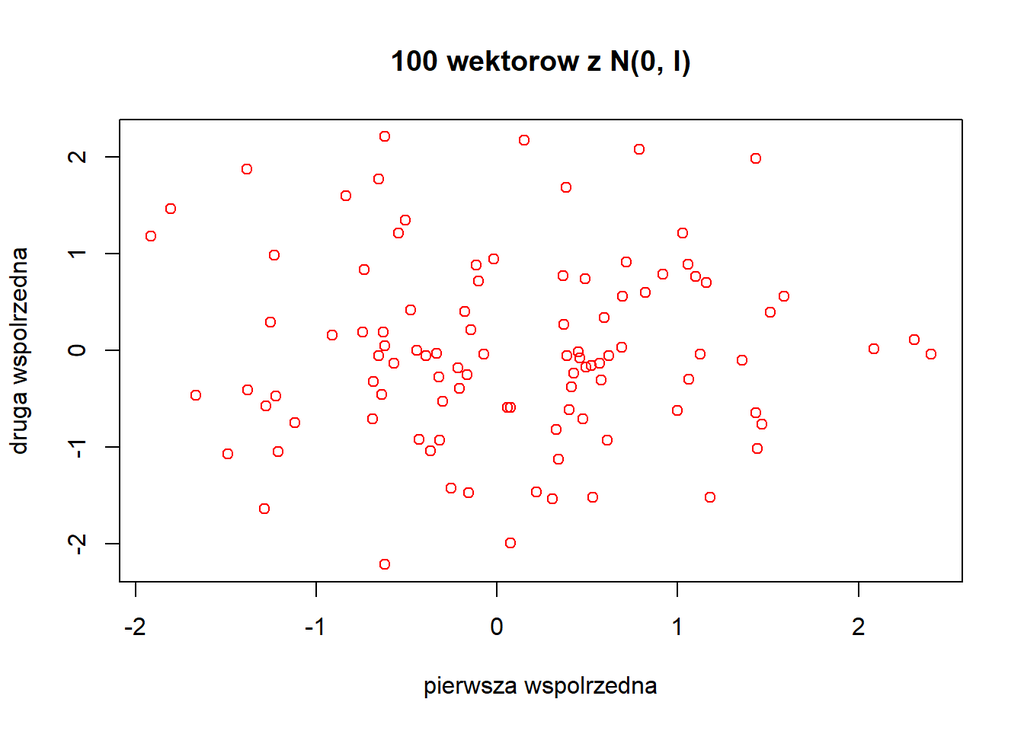

```r
X <- matrix(rnorm(200, 0, 1), nrow = 2, ncol = 100)
plot(t(X), main = "100 wektorow z N(0, I)", xlab = "pierwsza wspolrzedna", ylab = "druga wspolrzedna", col = "red")
```

### Zadanie 2

Wyznacz przeksztalcenia liniowe, ktore przeksztalca wyzej otrzymana chmure punktow w chmure z rozkladu N(µ, Σ), gdzie

µ = (4, 2),  
Σ1 =  
1 0.9  
0.9 1

µ = (4, 2),  
Σ2 =  
1 −0.9  
−0.9 1

µ = (4, 2),  
Σ3 =  
9 0  
0 1

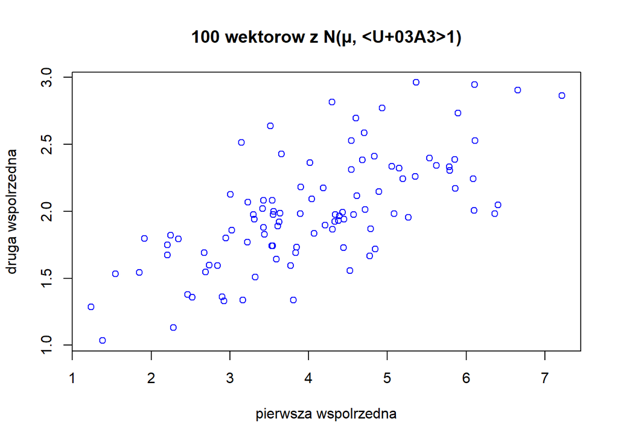

```r
A <- chol(matrix(c(1,0.9,0.9,1), 2))
Y <- A %*% X + matrix(c(rep(4, 100), rep(2, 100)), nrow = 2, byrow = T)
plot(t(Y), main = "100 wektorow z N(µ, Σ1)", xlab = "pierwsza wspolrzedna", ylab = "druga wspolrzedna", col = "blue")
```

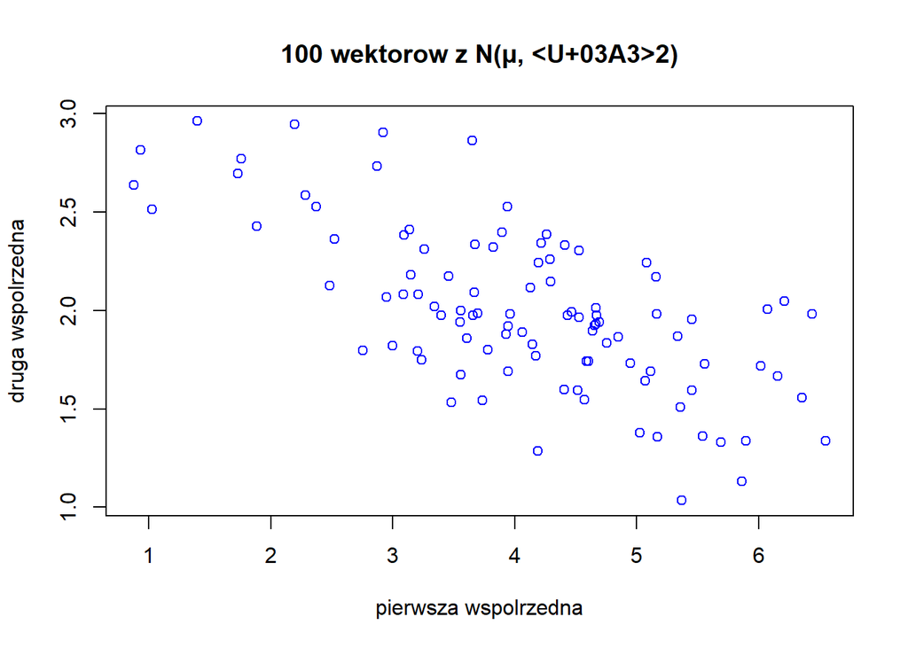

```r
A1 <- chol(matrix(c(1,-0.9,-0.9,1), 2))
Y1 <- A1 %*% X + matrix(c(rep(4, 100), rep(2, 100)), nrow = 2, byrow = T)
plot(t(Y1), main = "100 wektorow z N(µ, Σ2)", xlab = "pierwsza wspolrzedna", ylab = "druga wspolrzedna", col = "blue")
```

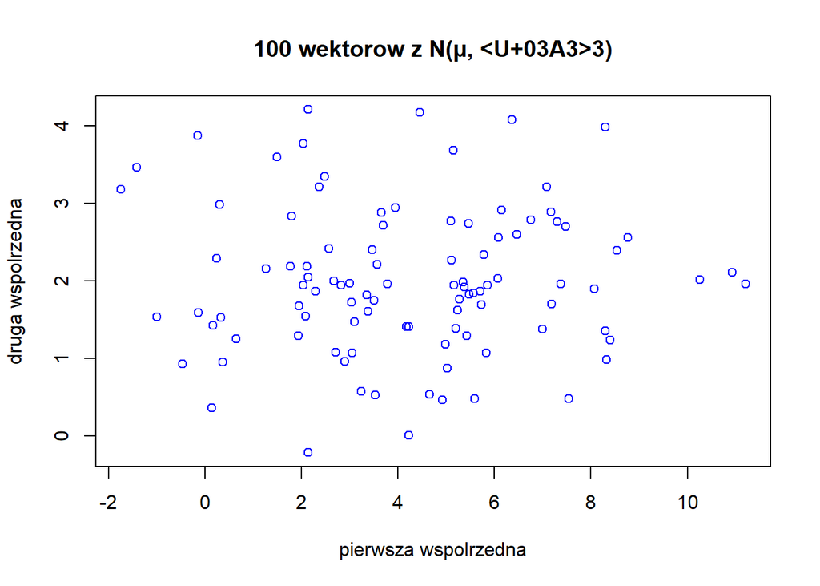

```r
A2 <- chol(matrix(c(9,0,0,1), 2))
Y2 <- A2 %*% X + matrix(c(rep(4, 100), rep(2, 100)), nrow = 2, byrow = T)
plot(t(Y2), main = "100 wektorow z N(µ, Σ3)", xlab = "pierwsza wspolrzedna", ylab = "druga wspolrzedna", col = "blue")
```

### Zadanie 3

Korzystajac z funkcji rnorm w R wygeneruj 200 wektorow losowych z rozkladu wielowymiarowego normalnego N(0, I100×100). Uzyskane dane zapisz w macierzy X200×100, ktorej wiersze zawieraj¸a kolejne wygenerowane wektory losowe. Nastepnie wyznacz macierz A tak, aby macierz X˜ = XA zawierala 200 wektorow z rozkladu wielowymiarowego normalnego N(0, Σ100×100), gdzie Σ(i, i) = 1 i Σ(i, j) = 0.9 dla i != j. Zweryfikuj wyniki wyliczajac srednia i rysujac histogram probkowych wariancji wspolrzednych wektora X˜ a tak˙ze probkowych kowariancji miedzy roznymi wspolrzednymi tego wektora.

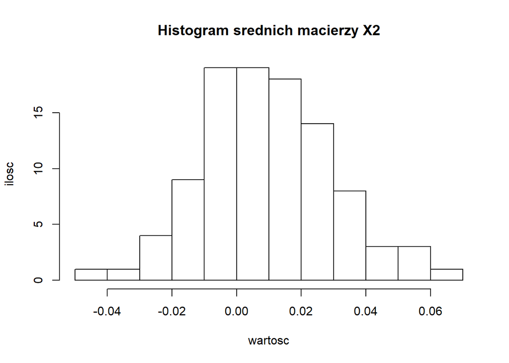

```r
X1 <- matrix(rnorm(100*200, 0, 1), nrow = 200, ncol = 100)
v <- c()
for (i in 1:10000) {
  v[i] <- if (i %in% seq(from = 1, to = 10000, by = 101)) 1 else 0.9
}
Sigma_ <- matrix(v, 100, 100)
A <- chol(Sigma_)
X2 <- X1 %*% A

mean_vector <- c()
var_vector <- c()

for(i in 1:100){
  mean_vector <- c(mean_vector, mean(X2[, i]))
  var_vector <- c(var_vector, var(X2[, i]))
}

hist(mean_vector, main = paste("Histogram srednich macierzy X2"), ylab = "ilosc", xlab = "wartosc", nclass = 10)
```

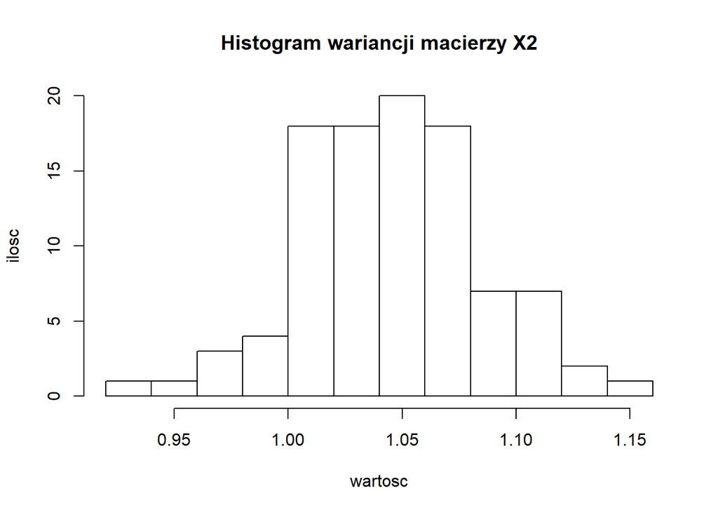

```r
hist(var_vector, main = paste("Histogram wariancji macierzy X2"), ylab = "ilosc", xlab = "wartosc", nclass = 10)
```

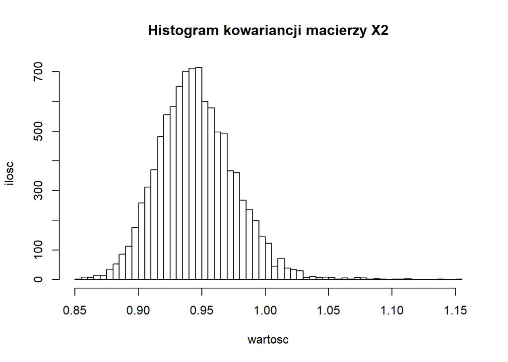

```r
cov_X2 <- cov(X2)
hist(cov_X2, main = paste("Histogram kowariancji macierzy X2"), ylab = "ilosc", xlab = "wartosc", nclass = 100)
```

### Wnioski

Zadanie 1: Dostalismy chmure punktow stu wektorow z rozkladu dwuwymiarowego normalnego N(0, I). Mozna zauwazyc, ze najwiecej punktow znajduje sie w poblizu punktu (0,0) zgodnie z nasza intuicja.

Zadanie 2: W tym zadaniu zobaczylismy jakim silnym narzedziem jest dekompozycja choleskiego. Dzieki tej nowo poznanej technice moglismy wyznaczyc szukana macierz (przeksztalcenie liniowe) z zadania w dwoch krokach. Dekompozycja choleskiego polega na tym, aby symetryczna, dodatnio okreslona macierz rozlozyc na iloczyn dwoch macierzy A oraz A-transponowane, gdzie A jest dolna macierza trojkatna, a A-transponowane jest jej transpozycja.